# Evaluación 1

Joshua

Mon Nov 26 17:54:33 2018

## Pregunta 0

Necesitaremos algunos paquetes para trabajar. Instale los siguientes paquetes: babynames, nycflights13, maps y carguelos (con `library`) junto al tidyverse.

## Pregunta 1

Considere, la tabla `births` del paquete `babynames`. Esto es:

```r
library(tidyverse)

data("births", package = "babynames")
births
```

[output not shown]

¿Cuántas columnas y filas posee la tabla *births*?

## Pregunta 2

Considere, la tabla `births` del paquete `babynames`. Estudie los nacimientos por años en EE.UU:

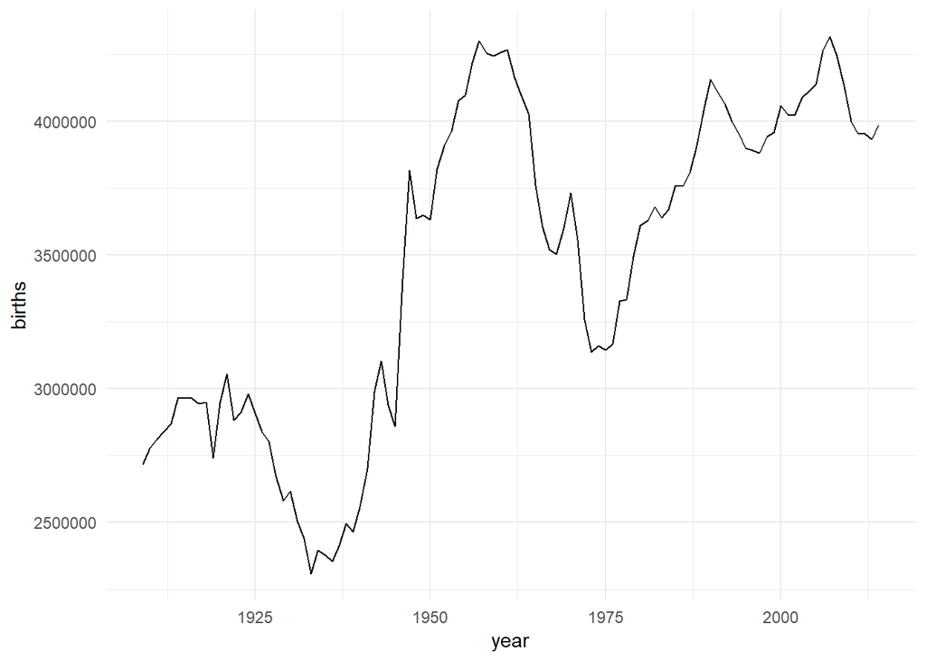

```r
theme_set(theme_minimal())

ggplot(births) +
  geom_line(aes(year, births))
```

¿En que *decada* se obtuvo la menor cantidad de nacimientos?

## Pregunta 3

Considerando ahora la tabla `babynames` del paquete `babynames`:

```r
data("babynames", package = "babynames")
glimpse(babynames)
```

```
## Observations: 1,858,689
## Variables: 5
## $ year <dbl> 1880, 1880, 1880, 1880, 1880, 1880, 1880, 1880, 1880, 188...
## $ sex  <chr> "F", "F", "F", "F", "F", "F", "F", "F", "F", "F", "F", "F...
## $ name <chr> "Mary", "Anna", "Emma", "Elizabeth", "Minnie", "Margaret"...
## $ n    <int> 7065, 2604, 2003, 1939, 1746, 1578, 1472, 1414, 1320, 128...
## $ prop <dbl> 0.072384329, 0.026679234, 0.020521700, 0.019865989, 0.017...
```

Una tabla con cinco variables: año, sexo, nombre, n y prop (n dividido por el número total de solicitantes en ese año, lo que significa que las proporciones son de personas de ese género con ese nombre nacido en ese año).

Realice el proceso necesario para obtener la misma estructura en cuanto a *columnas* que la tabla `births`.

## Pregunta 4

Genere un data frame partiendo de la tabla babyanes `babynames` y conteniendo los nacimientos de personas de género femenino con el nombre *Nala*, *Ariel* y *Elsa* desde los años 1980 en adelante.

## Pregunta 5

Con el data frame obtenido en la pregunta anterior genere un gráfico que contenga la información de los nacimientos por año de cada uno de los nombres mencionados y **mencione** una hipótesis/suposición al respecto de lo observado.

hint: Use `facet_wrap(~ name, scales = "free_y")`.

## Pregunta 6

Utilizando la tablas `airports` (aeropuertos) y `flights` (vuelos) del paquete `nycflights13` obtenga una tabla que contenga conteos de vuelos según su destino `dest` además de la longitud y latidud del aeropuerto (de destino).

## Pregunta 7

Apoyándose del siguiente gráfico

```r
us <- map_data("state")

glimpse(us)
```

```
## Observations: 15,537
## Variables: 6
## $ long      <dbl> -87.46201, -87.48493, -87.52503, -87.53076, -87.5708...
## $ lat       <dbl> 30.38968, 30.37249, 30.37249, 30.33239, 30.32665, 30...
## $ group     <dbl> 1, 1, 1, 1, 1, 1, 1, 1, 1, 1, 1, 1, 1, 1, 1, 1, 1, 1...
## $ order     <int> 1, 2, 3, 4, 5, 6, 7, 8, 9, 10, 11, 12, 13, 14, 15, 1...
## $ region    <chr> "alabama", "alabama", "alabama", "alabama", "alabama...
## $ subregion <chr> NA, NA, NA, NA, NA, NA, NA, NA, NA, NA, NA, NA, NA, ...
```

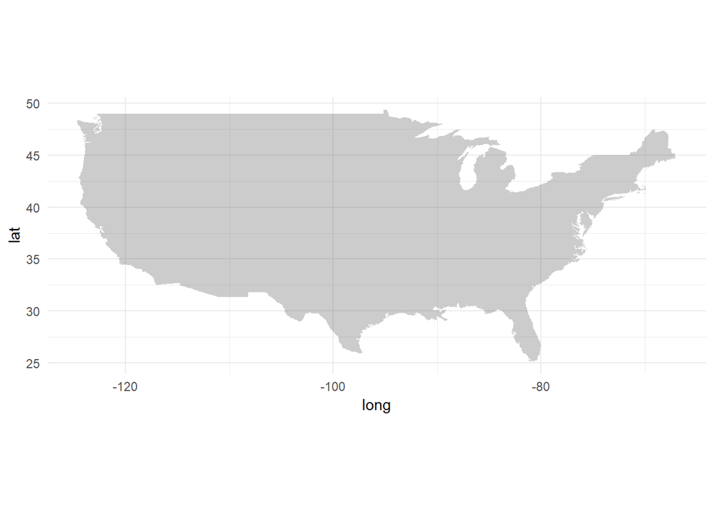

```r
ggmap <- ggplot() +
  geom_polygon(data = us, aes(long, lat, group = group),
               alpha = 0.25) +
  coord_fixed() # esto es para mantener la razón 1:1

ggmap
```

Agregue una capa de de puntos ubicando los aeropuertos obtenidos de la pregunta anterior y usando además: `aes(size = la_cantidad_de_vuelos_a_dicho_aeropuerto)`.

## Pregunta 9

Volviendo con `babynames`. Encuentre/invente/estudie alguna forma de detectar series de nombres que presenten anomalías o comportamientos *llamativos*.